# 5 Conjugate Models & Choosing Your Prior

Author

Johnny van Doorn

Published

June 8, 2026

By the end of this lecture, you will be able to:

- Explain what conjugacy means and why it is useful
- Apply the Beta–Binomial, Gamma–Poisson, and Normal–Normal update rules
- Choose a prior using effective sample size, moment matching, or a prior predictive check
- Run a prior sensitivity analysis in R

**Recommended Reading:** *Bayes Rules!* Chapter 5. Suggested exercises: 5.1, 5.2, 5.7, 5.8, 5.15, 5.16.

# Conjugate Models (Ch. 5)

## What Is Conjugacy?

$$f(\theta \mid y) \;\propto\; f(\theta) \cdot L(y \mid \theta)$$

A **conjugate prior** is one where the posterior belongs to the same distributional family as the prior — the hyperparameters simply absorb the data.

| Advantage | Why it matters |
| --- | --- |
| Closed-form posterior | No numerical integration needed |
| Transparent update | Hyperparameters = prior pseudo-data |
| Easy sensitivity analysis | Just change hyperparameters |

# The Beta–Binomial Model

## Research Context

> A digital CBT app is evaluated. What proportion $\theta$ of patients show meaningful improvement?
- $\theta \in [0,1]$: probability of improvement
- $Y \mid \theta \sim \text{Binomial}(n, \theta)$
- Prior: $\theta \sim \text{Beta}(\alpha, \beta)$

Prior literature suggests ~60% success. A pilot of 20 gives: $\alpha = 12$, $\beta = 8$ (ESS = 20, mean = 0.60).

## The Update Rule

$$\theta \sim \text{Beta}(\alpha, \beta) \qquad Y \mid \theta \sim \text{Bin}(n, \theta)$$

$$\boxed{\theta \mid y \;\sim\; \text{Beta}(\alpha + y,\;\; \beta + n - y)}$$

|  | Prior | Posterior |
| --- | --- | --- |
| “Successes” | $\alpha$ | $\alpha + y$ |
| “Failures” | $\beta$ | $\beta + n - y$ |
| Mean | $\alpha / (\alpha+\beta)$ | $(\alpha+y) / (\alpha+\beta+n)$ |

## R Code

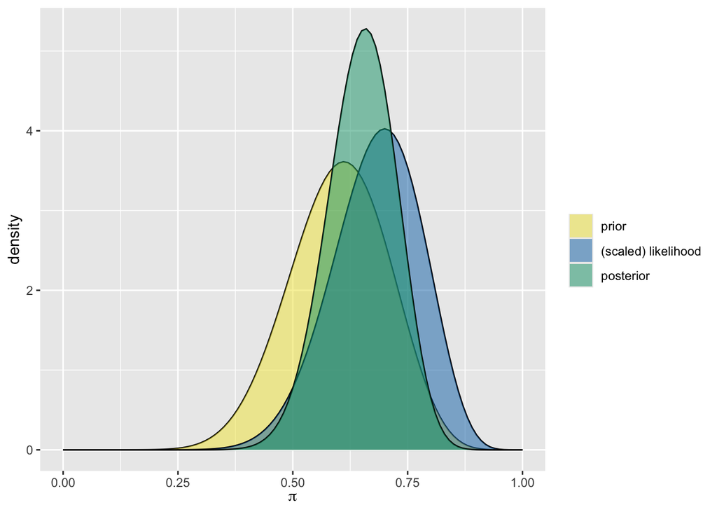

```r
library(bayesrules)

# Prior Beta(12, 8),  data: y = 14 successes out of n = 20
plot_beta_binomial(alpha = 12, beta = 8, y = 14, n = 20)
```

```r
summarize_beta_binomial(alpha = 12, beta = 8, y = 14, n = 20)
```

| model | alpha | beta | mean | mode | var | sd |
| --- | --- | --- | --- | --- | --- | --- |
| prior | 12 | 8 | 0.60 | 0.6111111 | 0.01142857 | 0.10690450 |
| posterior | 26 | 14 | 0.65 | 0.6578947 | 0.00554878 | 0.07449014 |

```r
# Posterior probability: P(theta > 0.70 | y)
pbeta(0.70, shape1 = 26, shape2 = 14, lower.tail = FALSE)
```

```
[1] 0.2602812
```

# The Gamma–Poisson Model

## Research Context

> A patient with OCD records intrusive thoughts each day for 7 days. What is the daily rate $\lambda$?
- $\lambda > 0$: mean daily count
- $Y_i \mid \lambda \overset{\text{iid}}{\sim} \text{Poisson}(\lambda)$
- Prior: $\lambda \sim \text{Gamma}(s, r)$

Literature suggests ~5 thoughts/day → $s = 5$, $r = 1$ (mean = 5, ESS $\approx$ 1 observation period).

## The Update Rule

$$\lambda \sim \text{Gamma}(s, r) \qquad Y_i \mid \lambda \overset{\text{iid}}{\sim} \text{Poisson}(\lambda)$$

$$\boxed{\lambda \mid \mathbf{y} \;\sim\; \text{Gamma}\!\left(s + \sum y_i,\;\; r + n\right)}$$

|  | Shape | Rate | Mean |
| --- | --- | --- | --- |
| Prior | $s$ | $r$ | $s/r$ |
| Posterior | $s + \sum y_i$ | $r + n$ | $(s + \sum y_i)/(r+n)$ |

## R Code

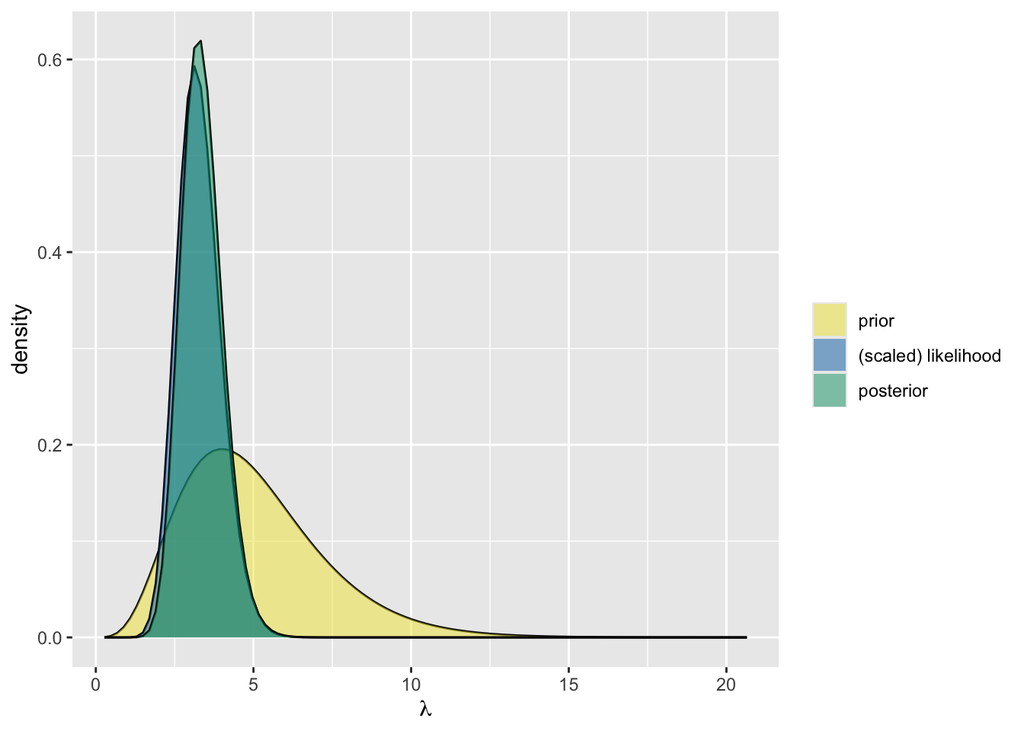

```r
library(bayesrules)

# Prior Gamma(5, 1),  data: 7 daily counts
y_vec <- c(6, 2, 2, 1, 3, 5, 3)

plot_gamma_poisson(shape = 5, rate = 1,
                   sum_y = sum(y_vec), n = length(y_vec))
```

```r
summarize_gamma_poisson(shape = 5, rate = 1,
                        sum_y = sum(y_vec), n = length(y_vec))
```

| model | shape | rate | mean | mode | var | sd |
| --- | --- | --- | --- | --- | --- | --- |
| prior | 5 | 1 | 5.000 | 4.00 | 5.000000 | 2.2360680 |
| posterior | 27 | 8 | 3.375 | 3.25 | 0.421875 | 0.6495191 |

# The Normal–Normal Model

## Research Context

> Stroop task. Literature: mean RT ~650 ms, known measurement error $\sigma = 50$ ms. You collect $n = 5$ participants.
- $\mu$: true mean RT
- $Y_i \mid \mu \overset{\text{iid}}{\sim} N(\mu, \sigma^2)$, $\sigma$ known
- Prior: $\mu \sim N(650, 100^2)$

## The Update Rule

The posterior mean is a **precision-weighted average** of prior and data:

$$\mu_\text{post} = w_\text{prior} \cdot \mu_0 + w_\text{data} \cdot \bar{y}$$

where $w_\text{prior} = \frac{\sigma^2}{n\tau^2 + \sigma^2}$ and $w_\text{data} = \frac{n\tau^2}{n\tau^2 + \sigma^2}$.

As $n$ grows, $w_\text{data} \to 1$ and the posterior concentrates on $\bar{y}$.

## R Code

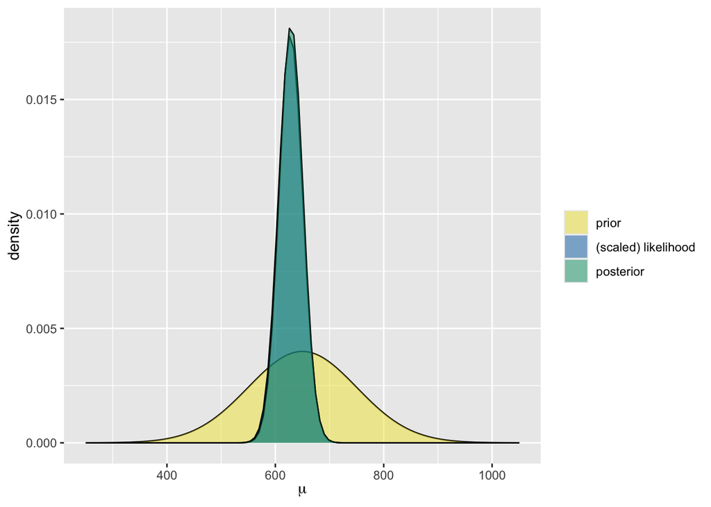

```r
library(bayesrules)

y_vec <- c(620, 590, 680, 640, 610)

plot_normal_normal(mean = 650, sd = 100,
                   sigma = 50, y_bar = mean(y_vec), n = 5)
```

```r
summarize_normal_normal(mean = 650, sd = 100,
                        sigma = 50, y_bar = mean(y_vec), n = 5)
```

| model | mean | mode | var | sd |
| --- | --- | --- | --- | --- |
| prior | 650.0000 | 650.0000 | 10000.0000 | 100.00000 |
| posterior | 629.0476 | 629.0476 | 476.1905 | 21.82179 |

# Choosing Your Prior

## Three Strategies

**Strategy 1: Effective Sample Size (ESS)**

Read hyperparameters as pseudo-data. ESS tells you how much prior information you’re asserting.

- **Beta($\alpha, \beta$):** ESS $= \alpha + \beta$. Beta(12, 8) acts like 20 prior observations.
- **Gamma($s, r$):** ESS $\approx r$ observation periods.
- **Normal($\mu_0, \tau^2$):** ESS $\approx \sigma^2 / \tau^2$ observations.

Rule of thumb: keep ESS small relative to $n$ unless you have substantial prior evidence.

**Strategy 2: Moment Matching**

Fix a target mean $\mu_0$ and SD $\sigma_0$, then solve for hyperparameters.

**Beta:**
$$\text{ESS} = \frac{\mu_0(1-\mu_0)}{\sigma_0^2} - 1, \quad \alpha = \mu_0 \cdot \text{ESS}, \quad \beta = (1-\mu_0) \cdot \text{ESS}$$

**Gamma:**
$$s = \frac{\mu_0^2}{\sigma_0^2}, \quad r = \frac{\mu_0}{\sigma_0^2}$$

**Example:** Expect ~70% success, SD = 0.10 → ESS = 20, $\alpha = 14$, $\beta = 6$ → Beta(14, 6).

**Strategy 3: Prior Predictive Check**

Simulate what the prior predicts *before* seeing data. If the simulated data look implausible, revise the prior.

1. Draw $\theta^{(i)}$ from the prior
2. Simulate $y^{(i)}$ from the likelihood at each $\theta^{(i)}$
3. Plot: does this look like realistic study data?

## Prior Predictive Check in R

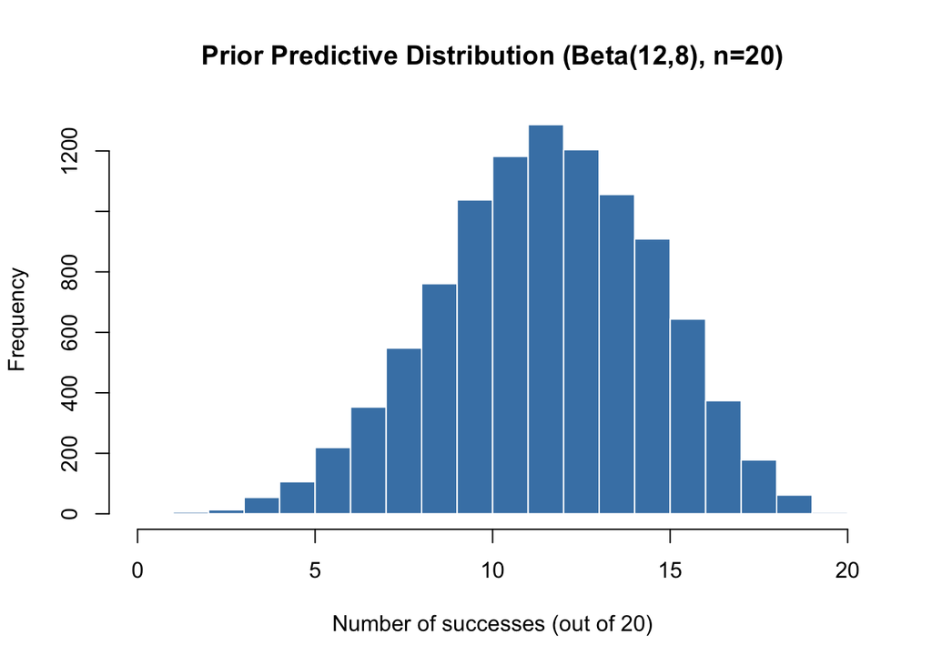

```r
# Prior Beta(12, 8), planning n = 20
theta_prior  <- rbeta(1e4, shape1 = 12, shape2 = 8)
y_prior_pred <- rbinom(1e4, size = 20, prob = theta_prior)

hist(y_prior_pred, breaks = 0:20,
     main = "Prior Predictive Distribution (Beta(12,8), n=20)",
     xlab = "Number of successes (out of 20)",
     col = "steelblue", border = "white")
```

## Prior Sensitivity Analysis

```r
# Same data: y = 14, n = 20. Three different priors.
priors <- list(
  "Beta(12,8)"  = c(12, 8),
  "Beta(2,2)"   = c(2,  2),
  "Beta(1,1)"   = c(1,  1)
)

for (nm in names(priors)) {
  a <- priors[[nm]][1]
  b <- priors[[nm]][2]
  post_mean <- (a + 14) / (a + b + 20)
  cat(nm, "→ posterior mean:", round(post_mean, 3), "\n")
}
```

```
Beta(12,8) → posterior mean: 0.65
Beta(2,2) → posterior mean: 0.667
Beta(1,1) → posterior mean: 0.682
```

No prior is “objective.” Beta(1,1) has ESS = 2 — it asserts that any success probability is equally plausible, from 0.001 to 0.999. That is itself an assumption, not a neutral stance.

# In-Class Exercises

## Exercise 1: Identify the Family

For each scenario below, identify the appropriate model (likelihood + prior family) and write the posterior update formula.

| Scenario | Data type | Model? |
| --- | --- | --- |
| % of phobia patients in remission after therapy | Binary | ? |
| # of nightmares per week | Counts | ? |
| Average BDI depression score (assume known SD) | Continuous | ? |
| # correct in a memory task (out of 30 words) | Binary | ? |

**Exercise**

Write:

1. The likelihood $Y \mid \theta \sim \ldots$
2. A conjugate prior $\theta \sim \ldots$
3. The posterior update rule

**Solution**

| Scenario | Likelihood | Prior | Posterior |
| --- | --- | --- | --- |
| Remission rate | Binomial$(n, \theta)$ | Beta$(\alpha, \beta)$ | Beta$(\alpha+y, \beta+n-y)$ |
| Nightmares/week | Poisson$(\lambda)$ | Gamma$(s, r)$ | Gamma$(s+\sum y_i, r+n)$ |
| Mean BDI | Normal$(\mu, \sigma^2)$ | Normal$(\mu_0, \tau^2)$ | Normal$(\mu_\text{post}, \sigma^2_\text{post})$ |
| Memory task | Binomial$(30, \theta)$ | Beta$(\alpha, \beta)$ | Beta$(\alpha+y, \beta+30-y)$ |

## Exercise 2: Placebo Effect Study

> 18 out of 25 participants report lower pain after receiving a sugar pill.

**Exercise**

1. Choose a Beta$(\alpha, \beta)$ prior. Justify your choice (use ESS reasoning).
2. Run a prior predictive check.
3. Derive and summarise the posterior using `bayesrules`.
4. Compute $P(\theta > 0.6 \mid y)$.
5. Repeat under Beta(1,1) — how much do conclusions change?

**Solution**

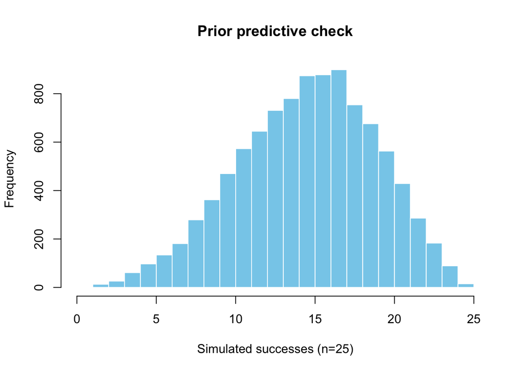

```r
library(bayesrules)

# 1. Prior: literature suggests placebo effects around 50–60%
#    Use Beta(6, 4): mean = 0.60, ESS = 10 (modest prior knowledge)
alpha_prior <- 6; beta_prior <- 4

# 2. Prior predictive check
theta_sim  <- rbeta(1e4, alpha_prior, beta_prior)
y_sim      <- rbinom(1e4, size = 25, prob = theta_sim)
hist(y_sim, breaks = 0:25, main = "Prior predictive check",
     xlab = "Simulated successes (n=25)", col = "skyblue", border = "white")
```

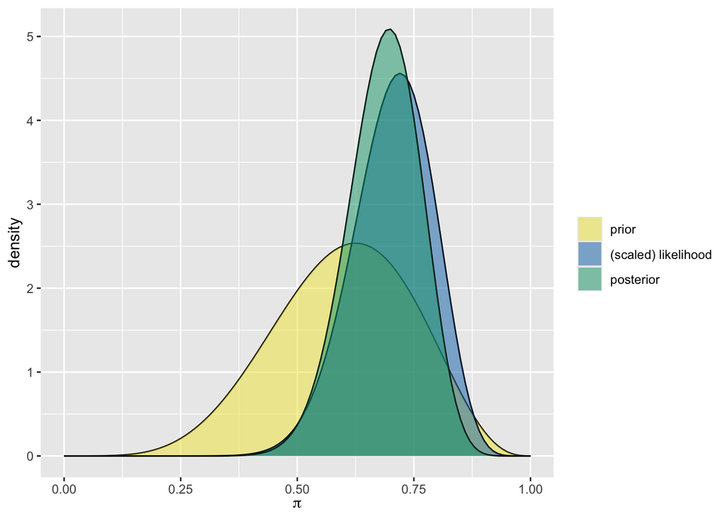

```r
# 3. Posterior: Beta(6+18, 4+7) = Beta(24, 11)
plot_beta_binomial(alpha = alpha_prior, beta = beta_prior, y = 18, n = 25)
```

```r
summarize_beta_binomial(alpha = alpha_prior, beta = beta_prior, y = 18, n = 25)
```

| model | alpha | beta | mean | mode | var | sd |
| --- | --- | --- | --- | --- | --- | --- |
| prior | 6 | 4 | 0.6000000 | 0.6250000 | 0.021818182 | 0.14770979 |
| posterior | 24 | 11 | 0.6857143 | 0.6969697 | 0.005986395 | 0.07737179 |

```r
# 4. P(theta > 0.60 | y)
pbeta(0.60, 24, 11, lower.tail = FALSE)
```

```
[1] 0.8616852
```

```r
# 5. Sensitivity: Beta(1,1)
summarize_beta_binomial(alpha = 1, beta = 1, y = 18, n = 25)
```

| model | alpha | beta | mean | mode | var | sd |
| --- | --- | --- | --- | --- | --- | --- |
| prior | 1 | 1 | 0.5000000 | NaN | 0.08333333 | 0.28867513 |
| posterior | 19 | 8 | 0.7037037 | 0.72 | 0.00744660 | 0.08629368 |

```r
pbeta(0.60, 19, 8, lower.tail = FALSE)
```

```
[1] 0.8784429
```

**Interpretation:** Under Beta(6,4), posterior mean ≈ 0.69, with strong evidence $\theta > 0.60$. Under the flat Beta(1,1), the posterior shifts only slightly (the data dominate). Conclusions are robust.

## Exercise 3: Choosing a Prior via Moment Matching

> A cognitive psychologist expects Stroop interference to add about 80 ms to reaction time, with considerable uncertainty (SD ≈ 30 ms). Measurement error is known to be $\sigma = 50$ ms.

**Exercise**

1. Use moment matching to find the Normal prior $\mu \sim N(\mu_0, \tau^2)$.
2. The researcher collects RTs: {720, 695, 740, 710, 680} ms. Derive the posterior.
3. Compute the posterior mean and compare it to the prior mean and sample mean.
4. How would the posterior change if the prior SD were 100 ms instead of 30 ms? What does this tell you about prior informativeness?

**Solution**

```r
library(bayesrules)

# 1. Prior from moment matching: mu_0 = 650 + 80 = 730, tau = 30
mu0  <- 730
tau  <- 30
sigma <- 50

# 2. Data
y <- c(720, 695, 740, 710, 680)
n <- length(y)
ybar <- mean(y)
cat("Sample mean:", ybar, "\n")
```

```
Sample mean: 709
```

```r
# Posterior via Normal-Normal update
sigma2 <- sigma^2; tau2 <- tau^2
sigma2_post <- 1 / (n / sigma2 + 1 / tau2)
mu_post     <- sigma2_post * (n * ybar / sigma2 + mu0 / tau2)
cat("Posterior mean:", round(mu_post, 1), "\n")
```

```
Posterior mean: 716.5
```

```r
cat("Posterior SD:",   round(sqrt(sigma2_post), 1), "\n")
```

```
Posterior SD: 17.9
```

```r
# 3. Comparison
cat("\nPrior mean:", mu0, "| Sample mean:", ybar, "| Posterior mean:", round(mu_post, 1), "\n")
```

```
Prior mean: 730 | Sample mean: 709 | Posterior mean: 716.5
```

```r
# 4. Vague prior (tau = 100)
tau2_vague   <- 100^2
sigma2_post2 <- 1 / (n / sigma2 + 1 / tau2_vague)
mu_post2     <- sigma2_post2 * (n * ybar / sigma2 + mu0 / tau2_vague)
cat("\nVague prior: posterior mean:", round(mu_post2, 1),
    " | posterior SD:", round(sqrt(sigma2_post2), 1), "\n")
```

```
Vague prior: posterior mean: 710  | posterior SD: 21.8
```

**Interpretation:** With a tight prior (SD = 30), the posterior is pulled toward 730 ms. With a vague prior (SD = 100), it follows the data much more closely. The prior’s ESS ($\approx \sigma^2/\tau^2$) drives this difference.

**Next lecture (June 10):** We move to posterior inference and hypothesis testing — how to summarise the posterior with credible intervals and use Bayes factors to compare hypotheses.